# Ordinal Multi-class Classification Problem on Harward GLOPOP Data

> Set the parameter as follows for the correct choice of the model:
> - params$modelType = 0 -> Ordinal Logistic Regression MASS::polr()
> - params$modelType = 1 -> LightGBM
> - params$modelType = 2 -> CatBoost
> - params$modelType = 3 -> Generalized Logistic Regression VGAM::vglm()

# Data Load & Prepare & Analyse

The data was obtained from global synthetic population database [GLOPOP-S](https://dataverse.harvard.edu/dataset.xhtml?persistentId=doi:10.7910/DVN/KJC3RH). They took the Demographic and Health Surveys for 45 countries including Tajikistan, categorized and harmonized it, as well as went through other data processing steps including creating regional marginal distributions.

In case of missing data in the regions, to fill it in, new data was modeled based on *k* number of regions with similar subnational human develepment index (SHDI) or SHDI relative to national HDI.

Then, marginals were scaled to match the region’s population size in 2015 to conserve the shape of the marginal distributions.

The following methods were used to generate a synthetic population from DHS and LIS: synthetic reconstruction, combinatorial optimization, statistical learning.

All the columns of the data, although represented as numbers, are of categorical type. Below is the description of the columns taken from the article [“A global dataset of 7 billion individuals with socio-economic characteristics”](https://www.nature.com/articles/s41597-024-03864-2) Nature journal.

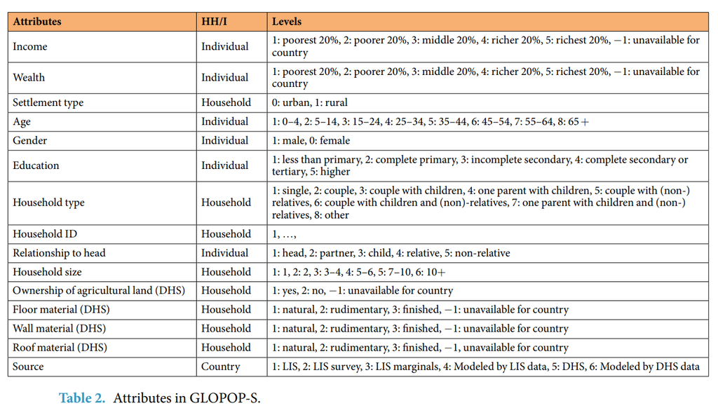

```r
library(dplyr)
library(R.utils)
library(Rcpp)
library(MASS)
library(purrr)
library(tidyr)
library(pROC)
library(ROCR)
library(caret)
library(DescTools)
library(lightgbm)
library(mlr3)
library(mlr3tuning)
library(paradox)
library(EIX)
library(catboost)
library(Information)
library(polycor)
library(brant)
library(gt)
library(car)
library(VGAM)
library(forcats)
library(FSelector)
library(gt)
```

## Exploratory Data Analysis

*General Observations*

- The dataset contains **9,269,799 records** with **16 variables**, all of which are categorical (encoded as integers).
- **No missing values** are present in any column (`Miss = 0` for all variables).

*Key Variable Insights*

**1. Household ID (`HID`)**

- High duplication: ~20 records per household on average, suggesting longitudinal or multi-member sampling.

**2. Household Relationships (`RELATE_HEAD`)**

- Majority are neither head nor primary dependents (median=3), hinting at extended family structures.

**3. Economic Indicators (`INCOME`, `WEALTH`)**

**4. Geographic/Rural Status (`RURAL`)** - Only 19.5% rural.

**5. Demographics (`AGE`, `GENDER`, `EDUC`)**

**6. Household Structure (`HHTYPE`, `HHSIZE_CAT`)**

- **`HHTYPE`**: Has complex non-ordinal categories. No conclusions based on numeric representation of groups.
- **`HHSIZE_CAT`**: Median = 5 out of 6 categories, mean = 4.54, suggesting larger households.

**7. Housing Quality (`FLOOR`, `WALL`, `ROOF`)**

**8. Agriculture (`AGR_CONNERSHIP`)**

- **Binary (0/1)**: 52.1% have agricultural connections (mean = 0.521), reflecting Tajikistan’s agrarian economy.

**9. Region (`REGION`)**

- **5 regions**: Mean = 2.86 (median = 3), with values spread across categories.

```r
source('C:\\Users\\SNurubloeva\\Documents\\Projects\\GLOPOP_S_tj\\functions.R')

OutputEDAofDataset(df = DF, IsTrainSet = TRUE)
```

[output not shown]

**Exploratory Data Analysis** (EDA)

|  | Type | Recs | **Miss** | **Unique** | Min | Q25 | Q50 | Avg | Q75 | Max | StDv | Neg | Zero | Pos | OutLo | OutHi | Q95 | Q96 | Q97 |
| --- | --- | --- | --- | --- | --- | --- | --- | --- | --- | --- | --- | --- | --- | --- | --- | --- | --- | --- | --- |
| HID | Num/Int | 9 269 799 | 0 | 448 902 | 1 | 100686 | 206409 | 208566.117 | 313508 | 448902 | 125379.739 | 0 | 0 | 9 269 799 | 0 | 0 | 406766 | 411043 | 415501 |
| RELATE_HEAD | Num/Int | 9 269 799 | 0 | 5 | 1 | 2 | 3 | 2.807 | 4 | 5 | 0.994 | 0 | 0 | 9 269 799 | 0 | 0 | 4 | 4 | 4 |
| INCOME | Num/Int | 9 269 799 | 0 | 1 | -1 | -1 | -1 | -1.000 | -1 | -1 | 0.000 | 9 269 799 | 0 | 0 | 0 | 0 | -1 | -1 | -1 |
| WEALTH | Num/Int | 9 269 799 | 0 | 5 | 1 | 2 | 3 | 2.979 | 4 | 5 | 1.407 | 0 | 0 | 9 269 799 | 0 | 0 | 5 | 5 | 5 |
| RURAL | Num/Int | 9 269 799 | 0 | 2 | 0 | 0 | 0 | 0.195 | 0 | 1 | 0.396 | 0 | 7 464 316 | 1 805 483 | 0 | 1 805 483 | 1 | 1 | 1 |
| AGE | Num/Int | 9 269 799 | 0 | 8 | 1 | 2 | 3 | 3.616 | 5 | 8 | 1.990 | 0 | 0 | 9 269 799 | 0 | 0 | 7 | 8 | 8 |
| GENDER | Num/Int | 9 269 799 | 0 | 2 | 0 | 0 | 0 | 0.496 | 1 | 1 | 0.500 | 0 | 4 673 581 | 4 596 218 | 0 | 0 | 1 | 1 | 1 |
| EDUC | Num/Int | 9 269 799 | 0 | 5 | 1 | 1 | 3 | 2.959 | 4 | 5 | 1.465 | 0 | 0 | 9 269 799 | 0 | 0 | 5 | 5 | 5 |
| HHTYPE | Num/Int | 9 269 799 | 0 | 8 | 1 | 3 | 6 | 5.088 | 6 | 8 | 1.598 | 0 | 0 | 9 269 799 | 0 | 0 | 7 | 7 | 7 |
| HHSIZE_CAT | Num/Int | 9 269 799 | 0 | 6 | 1 | 4 | 5 | 4.536 | 5 | 6 | 0.999 | 0 | 0 | 9 269 799 | 214 285 | 0 | 6 | 6 | 6 |
| AGRI_OWNERSHIP | Num/Int | 9 269 799 | 0 | 2 | 0 | 0 | 1 | 0.521 | 1 | 1 | 0.500 | 0 | 4 441 291 | 4 828 508 | 0 | 0 | 1 | 1 | 1 |
| FLOOR | Num/Int | 9 269 799 | 0 | 3 | 1 | 2 | 3 | 2.278 | 3 | 3 | 0.818 | 0 | 0 | 9 269 799 | 0 | 0 | 3 | 3 | 3 |
| WALL | Num/Int | 9 269 799 | 0 | 3 | 1 | 1 | 3 | 2.077 | 3 | 3 | 0.964 | 0 | 0 | 9 269 799 | 0 | 0 | 3 | 3 | 3 |
| ROOF | Num/Int | 9 269 799 | 0 | 3 | 1 | 3 | 3 | 2.953 | 3 | 3 | 0.301 | 0 | 0 | 9 269 799 | 227 294 | 0 | 3 | 3 | 3 |
| SOURCE | Num/Int | 9 269 799 | 0 | 1 | 5 | 5 | 5 | 5.000 | 5 | 5 | 0.000 | 0 | 0 | 9 269 799 | 0 | 0 | 5 | 5 | 5 |
| REGION | Num/Int | 9 269 799 | 0 | 5 | 1 | 2 | 3 | 2.863 | 4 | 5 | 1.012 | 0 | 0 | 9 269 799 | 0 | 0 | 4 | 4 | 4 |

*Примечание:* Разведочный Анализ обучающей выборки исходного набора данных проведен пакетом [`{smbinning}`](https://CRAN.R-project.org/package=smbinning) версии 0.9.

```r
do_MissingValue_Analysis <-
  (nrow(DF) !=  nrow(na.omit(DF)))
```

## Homogeneity Test

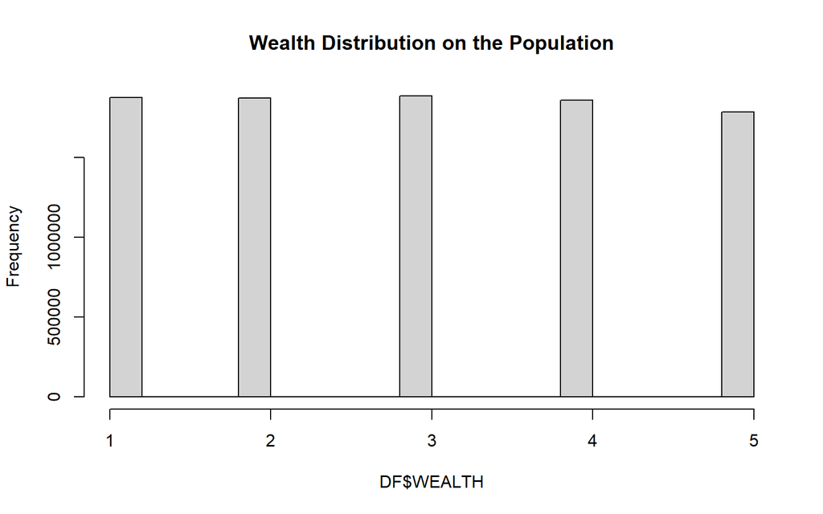

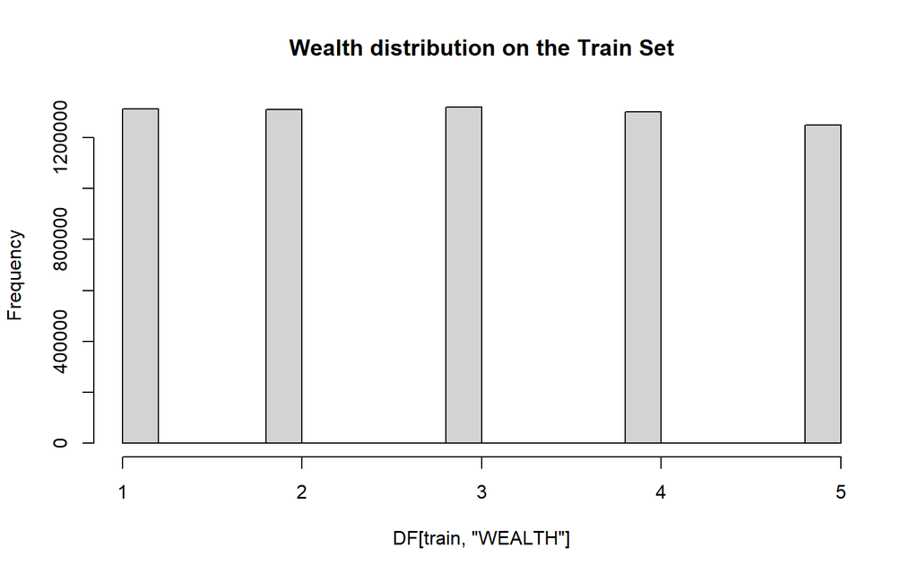

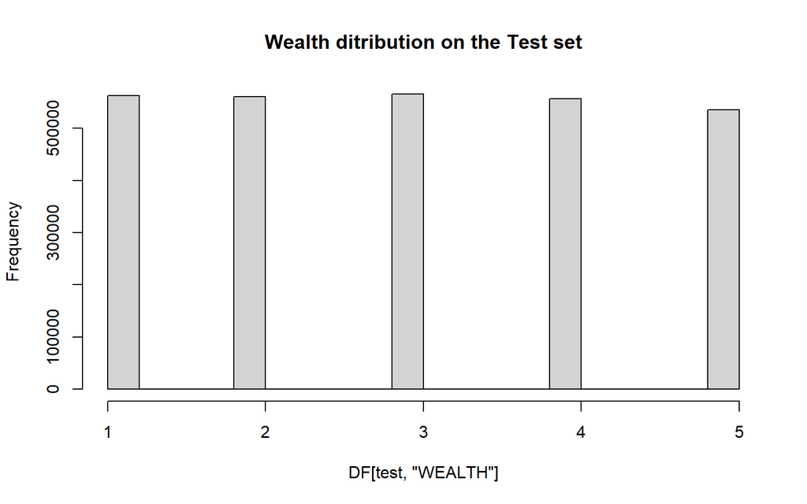

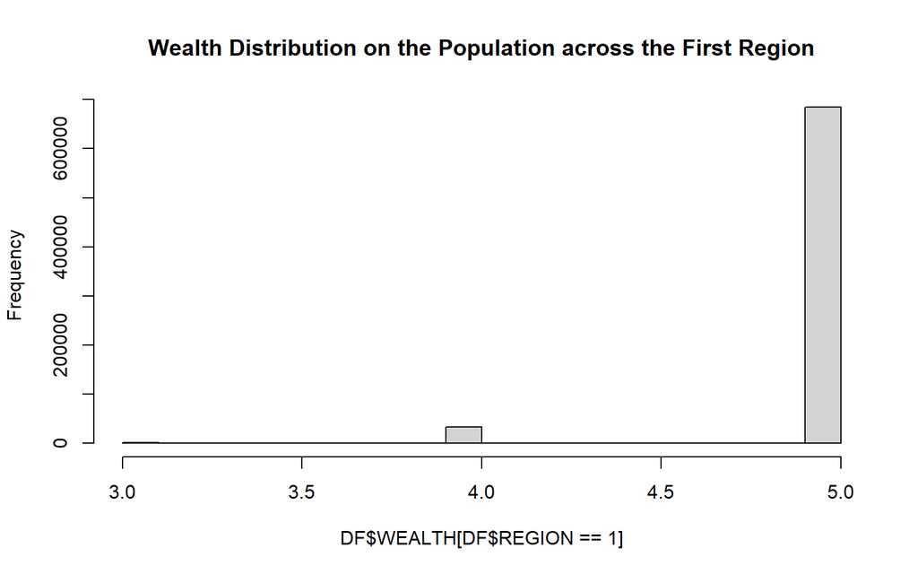

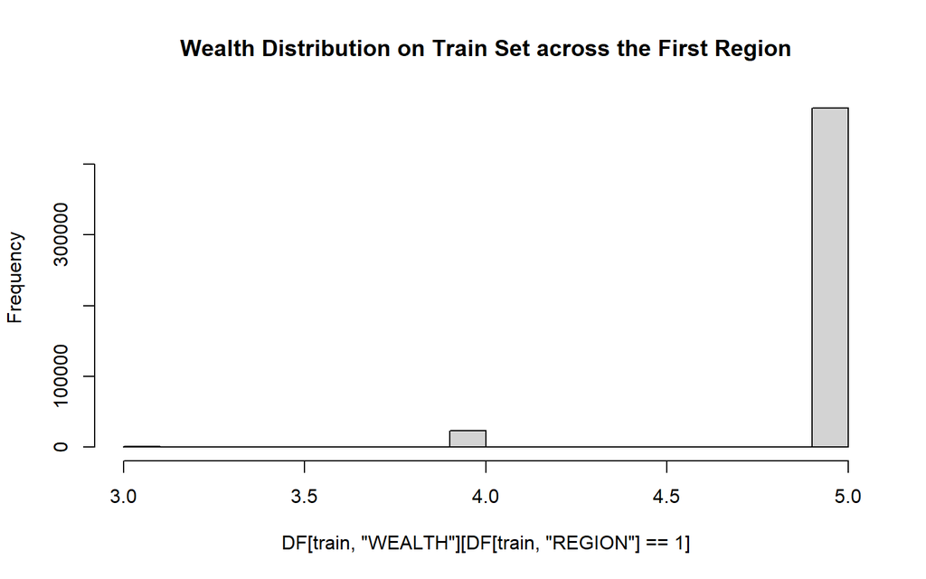

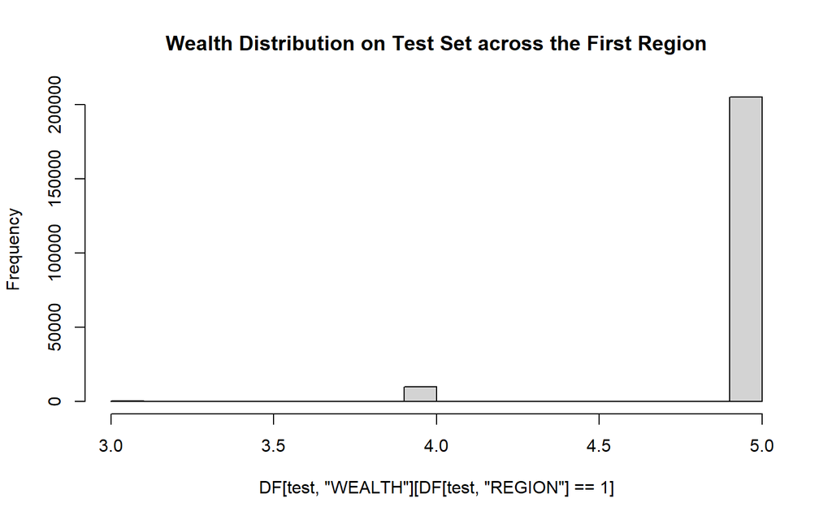

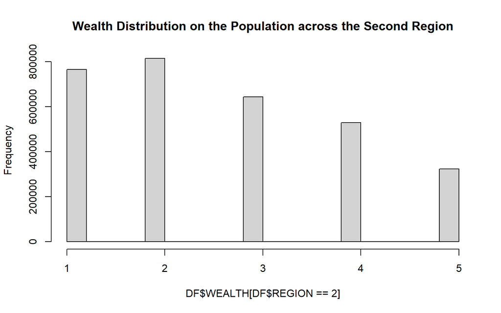

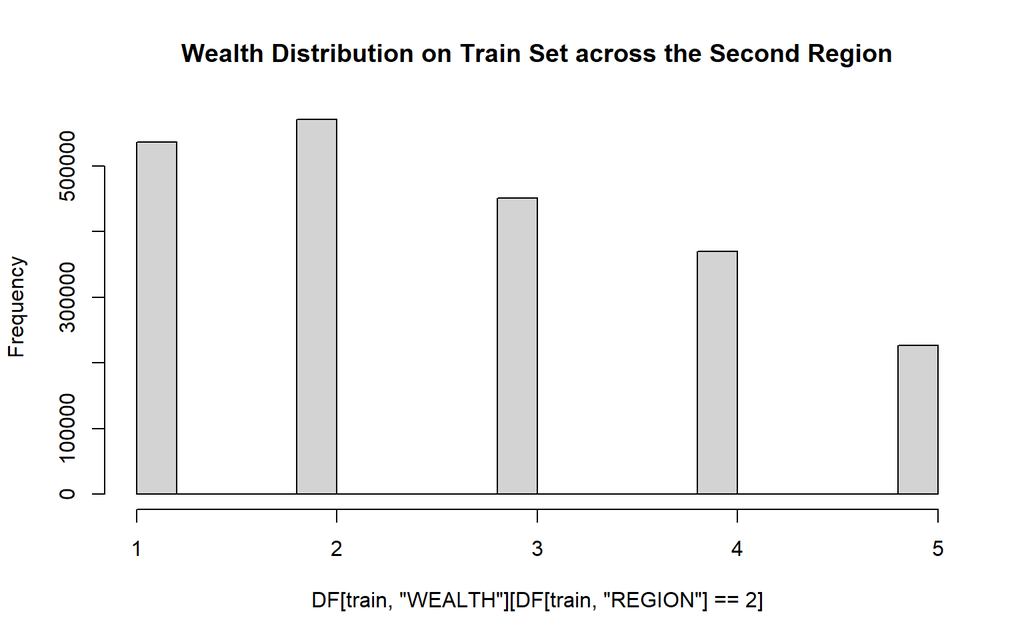

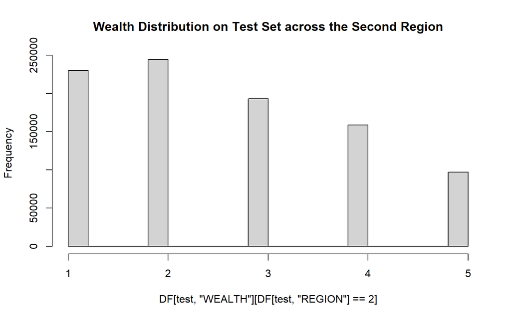

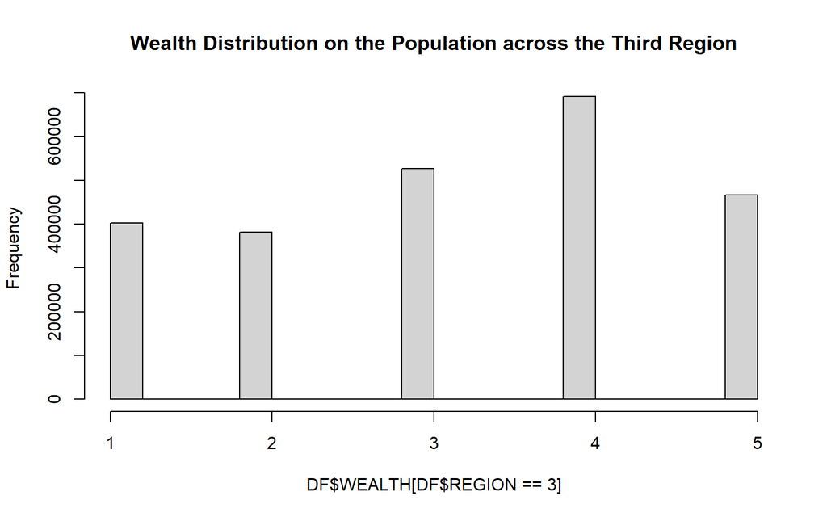

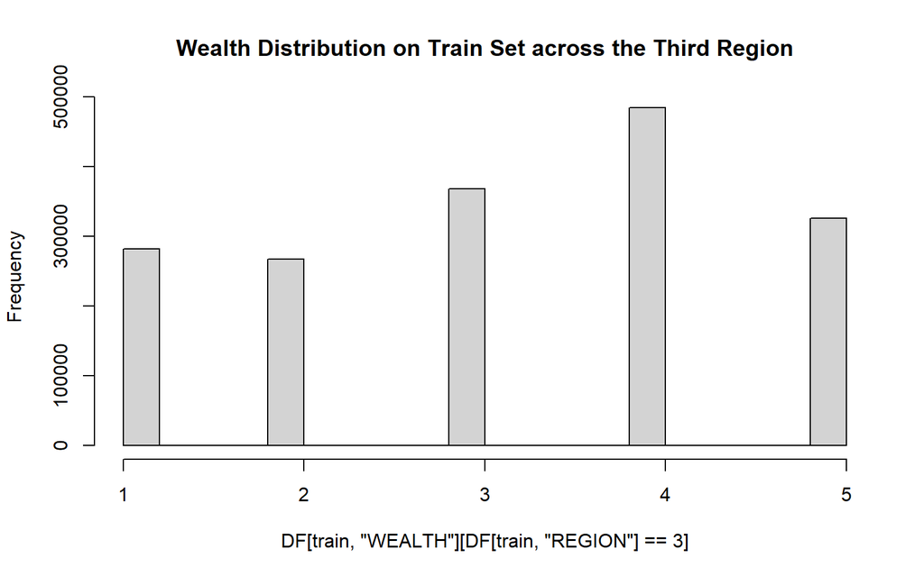

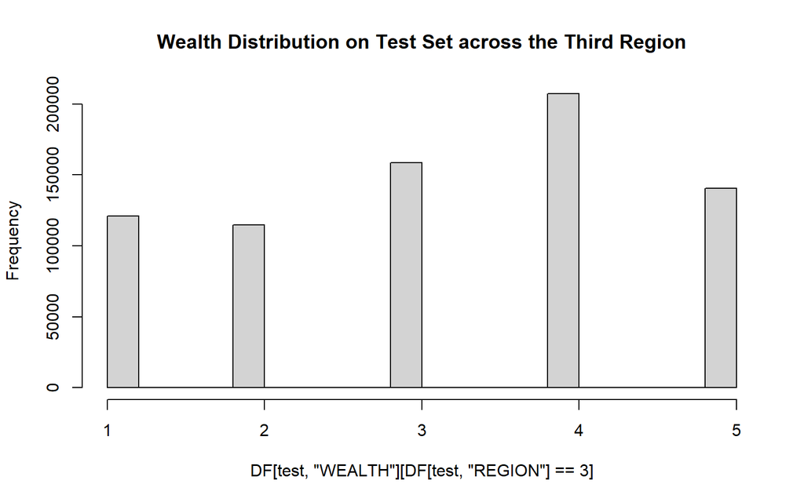

[6 more figures not shown]

## Relationships between WEALTH and other variables

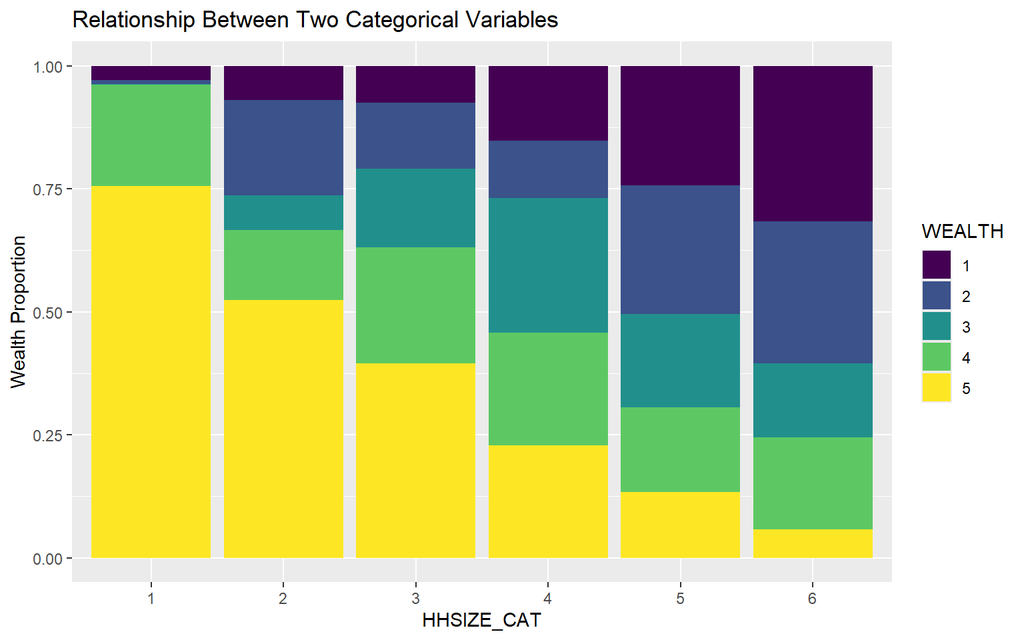

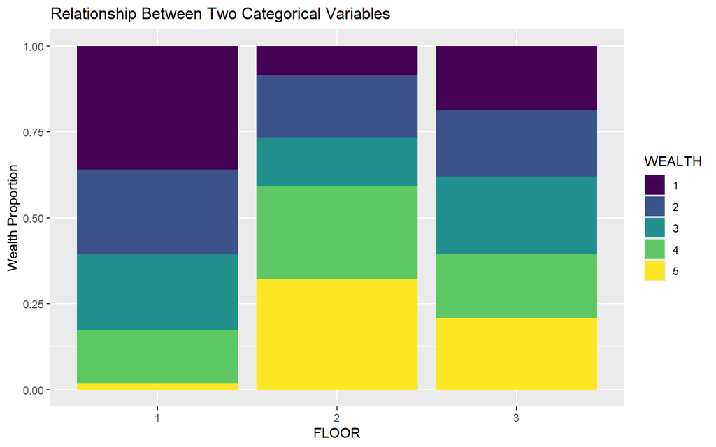

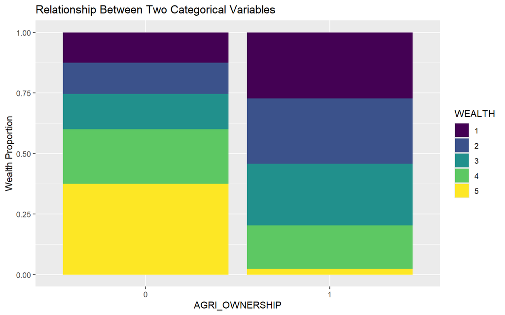

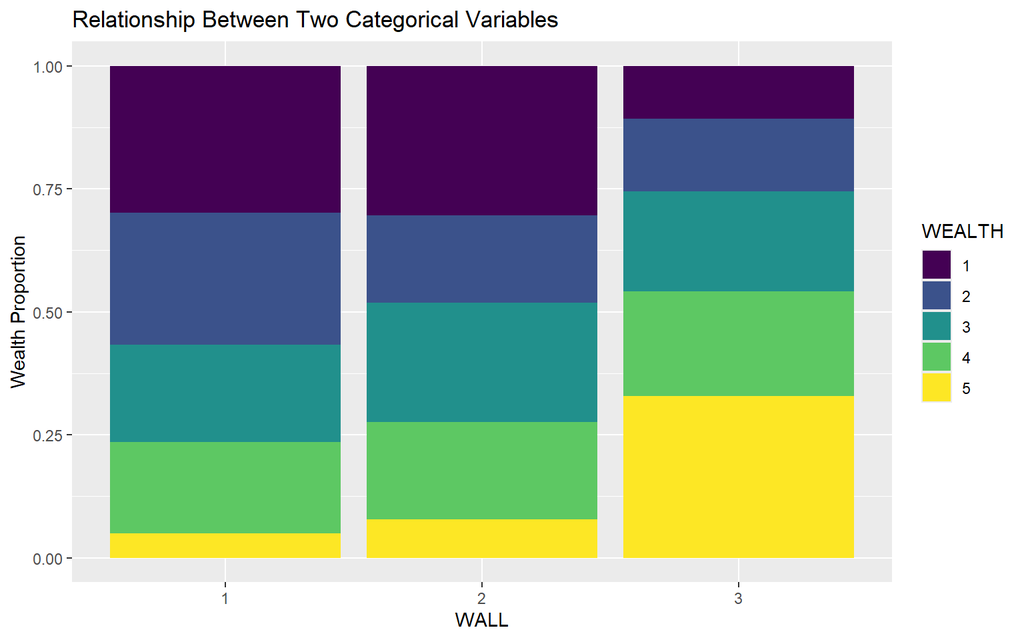

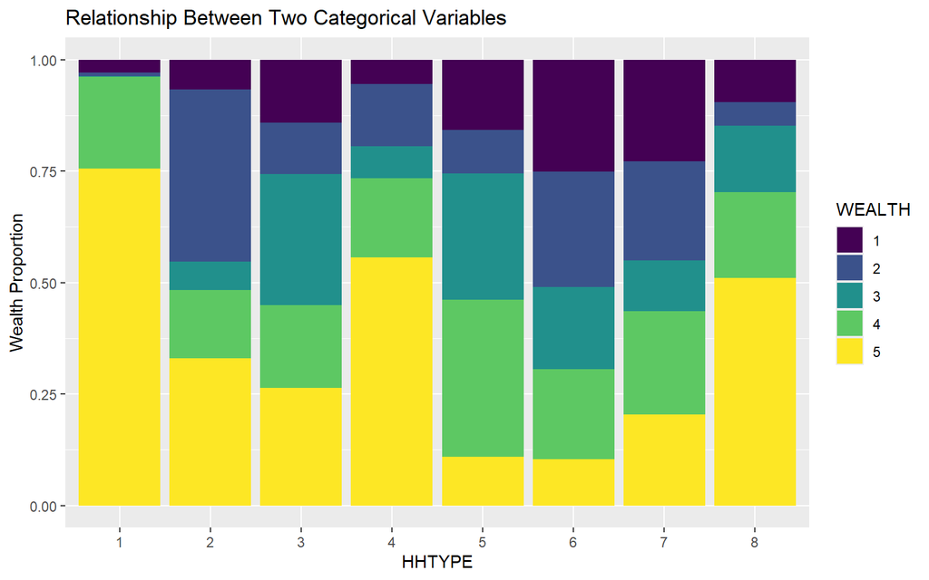

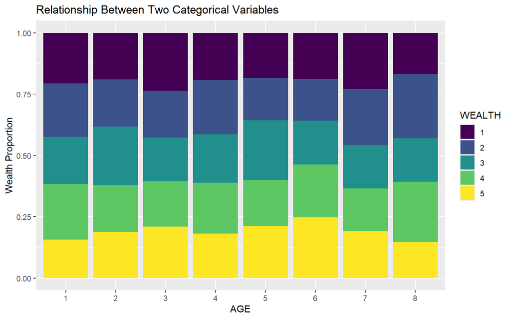

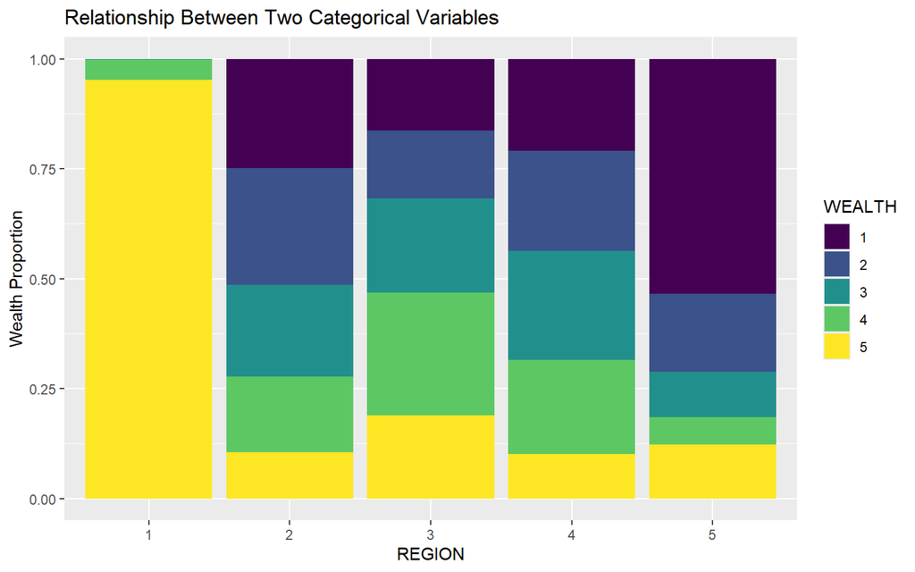

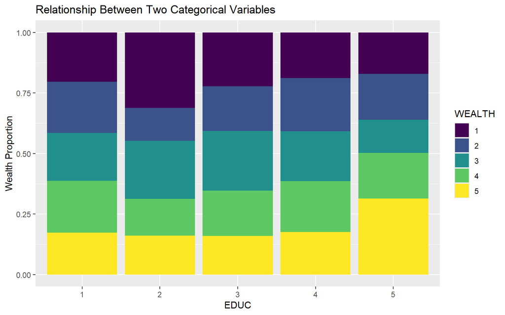

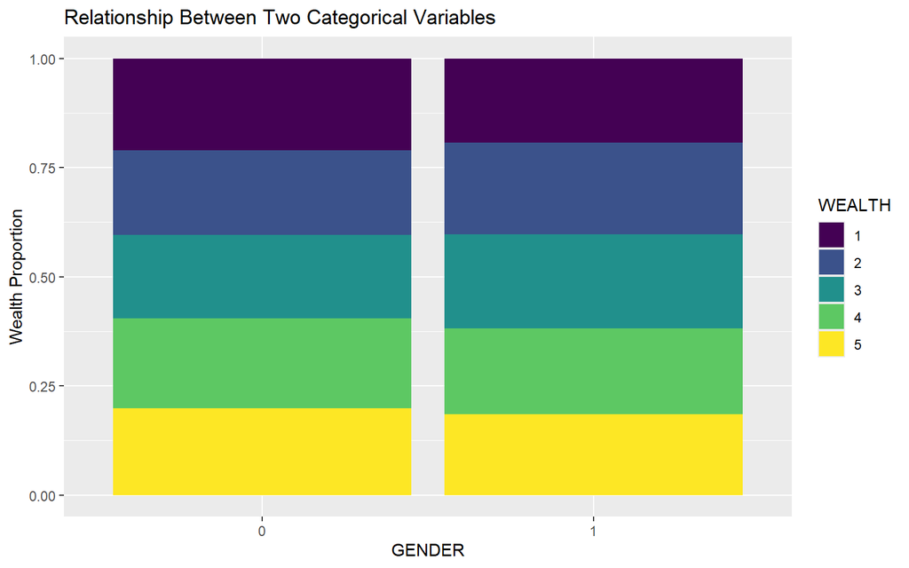

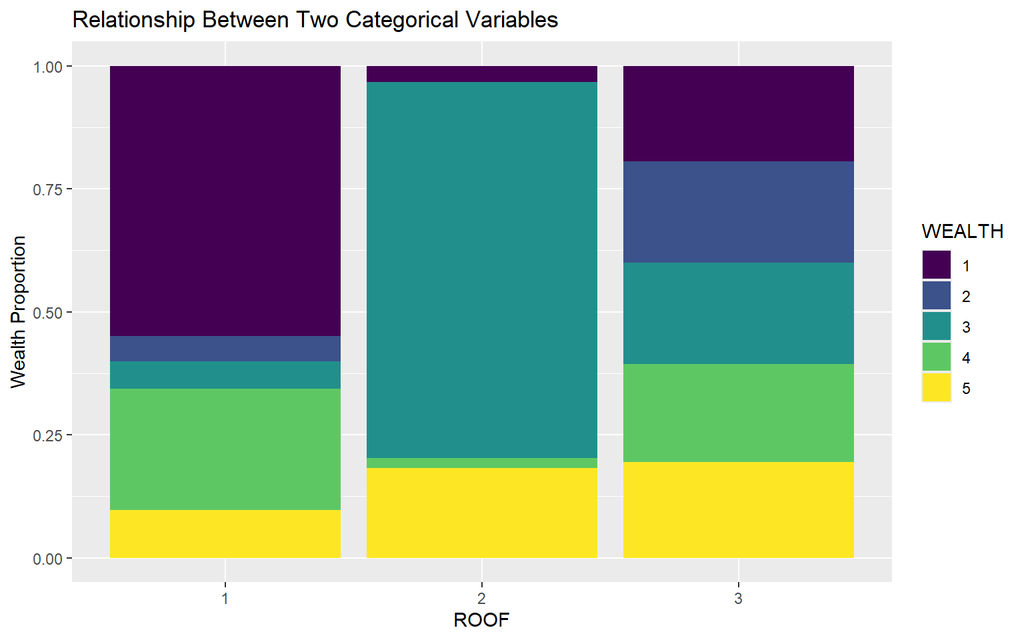

# Ordinal Logistic Regression Model

**Set `params$modelType = 0`**

## Model Assumptions

1. **Proportional odds**: The relationship between each predictor and the outcome is consistent across all outcome thresholds.
2. **No multicollinearity**: Check VIF (<5).
3. **Adequate sample size**: ~10-20 cases per predictor per outcome level.
4. **Meaningful ordinal outcome**: Categories must follow a logical order.

## Mutial Information

```
##                attr_importance
## AGE               0.0066949491
## GENDER            0.0008184556
## EDUC              0.0125136209
## HHTYPE            0.0659387786
## HHSIZE_CAT        0.0727038513
## AGRI_OWNERSHIP    0.1289645686
## FLOOR             0.0719929378
## WALL              0.0874742434
## ROOF              0.0108648835
## REGION            0.1495840274
```

## Correlation Matrix

| AGE | GENDER | EDUC | HHTYPE | HHSIZE_CAT | AGRI_OWNERSHIP | FLOOR | WALL | ROOF | REGION |
| --- | --- | --- | --- | --- | --- | --- | --- | --- | --- |
| 1.00 | −0.02 | 0.72 | −0.04 | −0.15 | −0.02 | −0.01 | 0.02 | −0.07 | 0.02 |
| −0.02 | 1.00 | 0.11 | −0.07 | −0.02 | 0.04 | 0.03 | 0.00 | −0.02 | 0.00 |
| 0.72 | 0.11 | 1.00 | −0.10 | −0.20 | −0.01 | 0.01 | 0.13 | −0.08 | −0.03 |
| −0.04 | −0.07 | −0.10 | 1.00 | 0.50 | 0.04 | −0.03 | −0.01 | 0.15 | 0.02 |
| −0.15 | −0.02 | −0.20 | 0.50 | 1.00 | −0.04 | −0.12 | −0.18 | 0.36 | 0.00 |
| −0.02 | 0.04 | −0.01 | 0.04 | −0.04 | 1.00 | 0.04 | −0.14 | −0.32 | 0.22 |
| −0.01 | 0.03 | 0.01 | −0.03 | −0.12 | 0.04 | 1.00 | 0.06 | −0.01 | 0.09 |
| 0.02 | 0.00 | 0.13 | −0.01 | −0.18 | −0.14 | 0.06 | 1.00 | 0.14 | −0.32 |
| −0.07 | −0.02 | −0.08 | 0.15 | 0.36 | −0.32 | −0.01 | 0.14 | 1.00 | −0.31 |
| 0.02 | 0.00 | −0.03 | 0.02 | 0.00 | 0.22 | 0.09 | −0.32 | −0.31 | 1.00 |

*Conclusion*: Based on the Mutual Information table and Correlation matrix the following features can be removed: `AGE` and `HHTYPE`.

## MASS::polr (Proportional Odds Logistic Regression)

A classical statistical model for ordinal outcomes that assumes proportional odds - the effect of predictors is consistent across all outcome thresholds. It provides interpretable coefficients but requires strict assumptions about data structure and linearity.

```r
for(i in 1:length(DF)){
  DF[[i]] <- factor(DF[[i]])
}

model <- MASS::polr( formula = WEALTH ~ EDUC + HHSIZE_CAT + WALL + ROOF + FLOOR + AGRI_OWNERSHIP , data = DF[1:1000000, c(features, "WEALTH")])  # + HHTYPE + AGE

model
```

```
## Call:
## MASS::polr(formula = WEALTH ~ EDUC + HHSIZE_CAT + WALL + ROOF +
##     FLOOR + AGRI_OWNERSHIP, data = DF[1:1000000, c(features,
##     "WEALTH")])
##
## Coefficients:
##          EDUC.L          EDUC.Q          EDUC.C          EDUC^4    HHSIZE_CAT.L
##       0.1077399       0.2283148      -0.3086780       0.2799945      -2.2316220
##    HHSIZE_CAT.Q    HHSIZE_CAT.C    HHSIZE_CAT^4    HHSIZE_CAT^5           WALL2
##      -0.2713608      -0.5475459       0.4753573      -0.1532835       0.3280669
##           WALL3           ROOF2           ROOF3          FLOOR2          FLOOR3
##       1.3573465       0.4965558       1.2079452       1.7566316       1.2148722
## AGRI_OWNERSHIP1
##      -2.0293344
##
## Intercepts:
##        1|2        2|3        3|4        4|5
## -0.4812981  0.8579052  2.0798659  3.6655017
##
## Residual Deviance: 2626380.86
## AIC: 2626420.86
```

## Check the proportionality of Odds Assumtion

```r
brant::brant(model)
```

```
## ----------------------------------------------------
## Test for     X2  df  probability
## ----------------------------------------------------
## Omnibus          100129.44   48  0
## EDUC.L           2034.8  3   0
## EDUC.Q           3126.64 3   0
## EDUC.C           2375.34 3   0
## EDUC^4           139.39  3   0
## HHSIZE_CAT.L     10546.93    3   0
## HHSIZE_CAT.Q     32189.8 3   0
## HHSIZE_CAT.C     1802.41 3   0
## HHSIZE_CAT^4     2792.69 3   0
## HHSIZE_CAT^5     957.51  3   0
## WALL2            883.39  3   0
## WALL3            20574.94    3   0
## ROOF2            7103.63 3   0
## ROOF3            31038.62    3   0
## FLOOR2           11596.78    3   0
## FLOOR3           12959.61    3   0
## AGRI_OWNERSHIP1  51492.14    3   0
## ----------------------------------------------------
##
## H0: Parallel Regression Assumption holds
```

## Check No Multicollinearity Assumption

```
##
## Re-fitting to get Hessian
```

```
##         Variable     GVIF Df GVIF^(1/(2*Df))
## 1     HHSIZE_CAT 1.223222  5        1.020353
## 2 AGRI_OWNERSHIP 1.134102  1        1.064942
## 3           WALL 1.109140  2        1.026234
## 4          FLOOR 1.100145  2        1.024148
## 5           ROOF 1.099745  2        1.024054
## 6           EDUC 1.086245  4        1.010395
```

# Light GBM (Light Gradient Boosting Machine)

**Set `params$modelType = 1`**

A high-performance gradient boosting framework optimized for speed and efficiency, using histogram-based algorithms and leaf-wise growth. Excels with large datasets, handling non-linear relationships automatically while offering GPU support and categorical feature handling. Requires careful tuning but delivers strong predictive accuracy with computational efficiency.

## Model Assumptions

1. **No strict linearity assumption**: Handles non-linear relationships.
2. **Preprocess categoricals**: Use `categorical_feature` or one-hot encoding.
3. **Hyperparameter tuning**: Critical for performance (e.g., `num_leaves`, `learning_rate`).
4. **Robust to outliers**: But extreme values may affect splits.

## Hyperparameter Tuning by Random Search

```r
if(params$hyperparams_tuning){
  dtrain <- lightgbm::lgb.Dataset(
    data = as.matrix(DF[ train , features]),
    label = Y_train,
    categorical_feature = features
  )

  # Define parameter search space
  param_grid <- list(
    num_leaves = sample(10:73, 20, replace = TRUE),
    learning_rate = runif(20, 0.05, 0.2),
    feature_fraction = runif(20, 0.5, 1.0),
    min_data_in_leaf = sample(3:150, 20, replace = TRUE),
    lambda_l1 = runif(20, 0, 3),
    lambda_l2 = runif(20, 0, 3),
    max_depth = sample(3:12, 20, replace = TRUE),
    min_gain_to_split = runif(20, 0, 0.1),
    bagging_fraction = runif(20, 0.6, 1.0),
    bagging_freq = sample(1:10, 20, replace = TRUE)
  )

  # Add fixed parameters
  fixed_params <- list(
    objective = "multiclass",
    metric = "multi_logloss",
    num_class = length(unique(Y_train)),
      min_split_gain = 0.01,
    feature_pre_filter = FALSE, # Critical for dynamic min_data_in_leaf
    verbose = 1
  )

  # Function to evaluate parameters
  evaluate_params <- function(parameters) {
    all_params <- c(parameters, fixed_params)

    # Cross-validation
    cv_result <- lightgbm::lgb.cv(
      params = all_params,
      data = dtrain,
      nrounds = 300,
      nfold = 5,
      early_stopping_rounds = 10,
      eval_freq = 10
    )

    # Return best score
    return(cv_result$best_score)
  }

  # Run random search
  results <- list()
  for (i in 1:20) {
    cat("Testing parameter set", i, "of 20\n")
    current_params <- lapply(param_grid, function(x) x[i])
    score <- evaluate_params(current_params)
    results[[i]] <- c(current_params, list(score = score))
  }

  # Find best parameters
    scores <- sapply(results, function(x) x$score)
    best_idx <- which.min(scores)
    best_params <- results[[best_idx]]

  # Remove score from best parameters
  best_params$score <- NULL

  # Combine with fixed parameters
  lgb_params <- c(best_params, fixed_params) } else {

  #   lgb_params <- list(
  #   objective = "multiclass",
  #   metric = "multi_logloss",
  #   num_class = 5,
  #   num_leaves = 65,
  #   min_data_in_leaf = 63,
  #   learning_rate = 0.1009604,
  #   feature_fraction = 0.9170543,
  #   min_split_gain = 0.01,
  #   feature_pre_filter = FALSE,
  #   lambda_l1 = 0.1002181,
  #   lambda_l2 = 0.2050984,
  #   verbose = 1
  # )


  lgb_params <- list(
    num_leaves = 73,
    learning_rate = 0.1603422,
    feature_fraction = 0.8519221,
    min_data_in_leaf = 20,
    lambda_l1 = 2.903614,
    lambda_l2 = 1.354935,
    max_depth = 12,
    min_gain_to_split = 0.005324554,
    bagging_fraction = 0.97738,
    bagging_freq = 3,
    objective = "multiclass",
    metric = "multi_logloss",
    num_class = 5,
    min_split_gain = 0.01,
    feature_pre_filter = FALSE,
    verbose = 1
  )

  }
```

```r
# Y_train <- as.integer(Y_train) - 1
# Y_test <- as.integer(Y_test) - 1


lgbm_train <- lightgbm::lgb.Dataset(data = as.matrix(DF[ train , features]), categorical_feature = features, label = Y_train)
lgbm_holdout <- lightgbm::lgb.Dataset(data = as.matrix(DF[ test , features]), categorical_feature = features, label = Y_test)

model <- lightgbm::lgb.train(params = lgb_params
                             # , force_col_wise = TRUE # If memory is not enough
                             # , max_bin = 255L
                             , data = lgbm_train
                             , valids = list(valid = lgbm_holdout) # decreases kappa and decreases overfiting
                             , early_stopping_rounds = 10
                             , eval_freq = 10 # 20
                             # , nrounds = 500 # 1000
                             )
# summary(model)
```

## Feature Interaction Table

```r
# load and process data

i=5
filename <- paste0('C:\\Users\\SNurubloeva\\Documents\\Projects\\GLOPOP_S_tj\\synthpop_', gdlcodes[i], '.dat.gz')
l = individuals_per_region[individuals_per_region$GDLcode == gdlcodes[i],]$Nr_individuals

con <- gzcon(file(filename, "rb"))

valid = readBin(con, integer(), n = l*n_columns)

close(con)

valid <- array(valid, dim=c(l, n_columns))
valid <- as.data.frame(valid)
valid$REGION <- i

colnames(valid) <- c('HID', 'RELATE_HEAD', 'INCOME', 'WEALTH', 'RURAL', 'AGE', 'GENDER',
                         'EDUC', 'HHTYPE', 'HHSIZE_CAT','AGRI_OWNERSHIP', 'FLOOR', 'WALL', 'ROOF', 'SOURCE', 'REGION')

ordinals <- c('WEALTH', 'AGE', 'EDUC', 'HHSIZE_CAT')

for(i in 1:15){
  ifelse( names(valid[i]) %in% ordinals, valid[[i]] <- factor(valid[[i]], ordered=TRUE), valid[[i]] <- factor(valid[[i]]))
  }
valid <- valid[ , !(names(valid) %in% c("SOURCE", "RURAL", "HID", "RELATE_HEAD", "INCOME"))]

# evaluate

valid_probs <- predict(model, as.matrix(valid[ , features]))

colnames(valid_probs) <- c("0", "1", "2", "3", "4")

valid_Y_test <- as.integer(valid[, ]$WEALTH) - 1

roc <- pROC::multiclass.roc(valid_Y_test, valid_probs)

print(roc$auc)

auc <- roc$auc[1]

gini <- auc*2 - 1
cat(paste("Gini on valid set:", gini), '\n')
```

# CatBoost Model

**Set `params$modelType = 2`**

An advanced gradient boosting implementation featuring native handling of categorical variables through ordered boosting and innovative approaches to missing data. Particularly robust for heterogeneous datasets. Shows high quality results in a moderate speed while not requiring preprocessing of categorical variables

## Model Assumptions

1. **Handles categoricals natively**: No need for one-hot encoding.
2. **Requires GPU for large data**: Optimal performance with GPU acceleration.
3. **Hyperparameter sensitivity**: Tune `depth`, `iterations`, and `learning_rate`.
4. **Automatic handling of missing values**: But imputation may still help.

```r
if(params$hyperparams_tuning){

  next

} else {

  cat_params <- list(
  loss_function = "MultiClass",
  iterations = 1000,
  depth = 6,
  learning_rate = 0.1,
  verbose = 100
  )

  }
```

```r
trainDF <- DF[sample(nrow(distinct(DF[train, ]))), ]   # distinct(DF[train, ])
Y_train <- as.integer(trainDF$WEALTH)

train_pool <- catboost.load_pool(data = trainDF[1:10000 , features], label = Y_train[1:10000]) #, cat_features = features
# train_pool <- catboost.load_pool(data = DF[train, features, ], label = Y_train)
test_pool <- catboost.load_pool(data = DF[test, features], label = Y_test) #, cat_features = features

model <- catboost.train(train_pool, params = cat_params)

trainDF <- NULL
```

```r
# Function to test all categorical pairs
test_all_chi_square <- function(df){
# cat_vars <- df %>% select(where(is.factor) |>
#                     select(where(~ nlevels(.) > 1)))

cat_vars <- purrr::keep(df, ~is.factor(.) && nlevels(.) > 1)

# Get all combinations
  var_pairs <- combn(names(cat_vars), 2, simplify = FALSE)

# Run chi-square tests
  results <- map_dfr(var_pairs, ~ {
    tbl <- table(cat_vars[[.x[1]]], cat_vars[[.x[2]]])
    test <- suppressWarnings(chisq.test(tbl))

    tibble(
      Variable1 = .x[1],
      Variable2 = .x[2],
      ChiSq = test$statistic,
      df = test$parameter,
      p_value = test$p.value,
      Warning = ifelse(any(test$expected < 5),
                      "Low expected counts",
                      "OK")
    )
  })

# Sort by most significant
  arrange(results, p_value)
}

# Usage (replace DF with your dataframe)
chi_results <- test_all_chi_square(DF)
print(chi_results, n = Inf)  # Show all results
```

```r
catboost.get_feature_importance(model = model, pool = train_pool, type = "FeatureImportance")
```

```r
Y_train <- as.integer(DF[train, ]$WEALTH) - 1
train_pool <- catboost.load_pool(data = DF[train, features], label = Y_train)


# TRAIN SET
train_probs <- catboost.predict(model, train_pool, prediction_type = "Probability")
train_Y_predicted <- catboost.predict(model, train_pool, prediction_type = "Class")
colnames(train_probs) <- c("0", "1", "2", "3", "4")

# TEST SET
probs <- catboost.predict(model, test_pool, prediction_type = "Probability")
Y_predicted <- catboost.predict(model, test_pool, prediction_type = "Class")
colnames(probs) <- c("0", "1", "2", "3", "4")

accuracy <- sum(Y_predicted == Y_test) / length(Y_test)
cat(paste("Accuracy:", accuracy))
```

# Generalized Ordinal Logistic Regression (using VGLM)

**Set `params$modelType = 3`**

A flexible framework for fitting various regression models, including extended ordinal logistic models that can relax the proportional odds assumption. This allows more flexibility and higher quality in compare to `polr`. Offers sophisticated modeling options like partial proportional odds and continuation ratio models.

As the Thomas W. Yee suggests in his article The VGAM Package for Categorical Data Analysis, “the framework is very well suited to many ‘classical’ regression models for categorical responses”.

## Model Assumptions

1. **Proportional odds**: The assumption of Ordinal Logistic Regression is relaxed on a feature if it’s included in family = cumulative(parallel = FALSE ~ .) of VGLM model.
   - requires homogeneity of the feature groups
2. **No multicollinearity**: Check VIF (<5).
3. **Adequate sample size**: ~10-20 cases per predictor per outcome level.
4. **Meaningful ordinal outcome**: Categories must follow a logical order.

```r
# getting rid of imbalances columns of variables HHSIZE_CAT, ROOF
DF$HHSIZE_CAT <- fct_collapse(DF$HHSIZE_CAT,
                                    "1_2" = c("1", "2"),
                                    "3_4" = c("3", "4"),
                                    "5_6" = c("5", "6")) %>% factor(., ordered = TRUE)

DF$ROOF <- fct_collapse(DF$ROOF,
                                "1_2" = c("1", "2"),
                                "3" = c("3")) %>% factor(., ordered = TRUE)

# DF$REGION <- fct_collapse(DF$REGION
#                           , "1_2" = c("1", "2")
#                           , "3_4" = c("3", "4"))

# Then use HHSIZE_CAT_RECODE in your model
model <- vglm(
  WEALTH ~ EDUC + AGRI_OWNERSHIP + FLOOR + WALL*ROOF + REGION + HHSIZE_CAT+ EDUC*AGRI_OWNERSHIP, #+ HHSIZE_CAT
  family = cumulative(parallel = FALSE ~ AGRI_OWNERSHIP + FLOOR + WALL),  # TRUE ~ EDUC + ROOF + REGION + HHSIZE_CAT
  data = DF[1:20000, ]
)

features <- c("EDUC", "HHSIZE_CAT", "AGRI_OWNERSHIP",
              "FLOOR", "WALL", "ROOF", "REGION", "AGE")
```

```r
# TRAIN
cumul_probs <- plogis(predict(model, DF[1:100000, features])) |> as.data.frame()

train_probs <- data.frame(matrix(nrow = nrow(cumul_probs), ncol = 0))
train_probs$P1 <- cumul_probs[, 1]  # P(Y = 1)
train_probs$P2 <- cumul_probs[, 2] - cumul_probs[, 1]  # P(Y = 2)
train_probs$P3 <- cumul_probs[, 3] - cumul_probs[, 2]  # P(Y = 3)
train_probs$P4 <- cumul_probs[, 4] - cumul_probs[, 3]  # P(Y = 4)
train_probs$P5 <- 1 - cumul_probs[, 4]           # P(Y = 5)

Y_train <- DF[1:100000, 'WEALTH']
names(train_probs) <- levels(Y_train)

# TEST
cumul_probs <- plogis(predict(model, DF[test, features])) |> as.data.frame()

probs <- data.frame(matrix(nrow = nrow(cumul_probs), ncol = 0))
probs$P1 <- cumul_probs[, 1]  # P(Y = 1)
probs$P2 <- cumul_probs[, 2] - cumul_probs[, 1]  # P(Y = 2)
probs$P3 <- cumul_probs[, 3] - cumul_probs[, 2]  # P(Y = 3)
probs$P4 <- cumul_probs[, 4] - cumul_probs[, 3]  # P(Y = 4)
probs$P5 <- 1 - cumul_probs[, 4]           # P(Y = 5)

Y_test <- DF[test, 'WEALTH']
names(probs) <- levels(Y_test)
```

```r
library(ggplot2)

# Extract coefficients and confidence intervals from vglm
coefs <- coef(model)
confints <- confint(model, level = 0.85)

# Create a data frame for plotting
df_plot <- data.frame(
  Variable = names(coefs),
  OR = exp(coefs),
  Lower = exp(confints[, 1]),
  Upper = exp(confints[, 2]),
  Significant = ifelse(confints[, 1] > 0 | confints[, 2] < 0, "Significant", "Not significant")
)

# Manually plot odds ratios
ggplot(df_plot, aes(x = Variable, y = OR, color = Significant)) +
  geom_point(size = 3) +
  geom_errorbar(aes(ymin = Lower, ymax = Upper), width = 0.2) +
  geom_hline(yintercept = 1, linetype = "dashed", color = "red") +
  scale_color_manual(values = c("Significant" = "#44bd32", "Not significant" = "orangered")) +
  coord_flip() +
  theme_minimal() +
  labs(title = "Odds Ratios (VGAM Model)", y = "Odds Ratio", x = "Predictor")
```

# Evaluation of a Model

> CURRENTLY THE Ordinal Logistic Regression MODEL IS BUILT. To change the model refer to the top of the page and change the parameter of the model type accordingly.

```r
# , eval = ifelse(params$modelType == 2, TRUE, FALSE)

roc <- pROC::multiclass.roc(Y_train, train_probs)

print(roc$auc)
```

```
## Multi-class area under the curve: 0.7417
```

```r
auc <- roc$auc[1]

gini <- auc*2 - 1
cat(paste("Gini on train set:", gini), '\n')
```

```
## Gini on train set: 0.483420297892295
```

```r
# if(params$modelType == 0){
#
#   Y_predicted <- as.numeric(probs) - 1
#
# }

if(params$modelType == 1){Y_predicted <- max.col(probs) -1}  # if (eval=ifelse(params$modelType == 3, TRUE, FALSE))

if(params$modelType == 3 | params$modelType == 0 ){Y_predicted <- max.col(probs)}

# CONFUSION MATRIX
print(paste0("Confusion Matrix"))
```

```
## [1] "Confusion Matrix"
```

```r
if( params$modelType==0){
  conf_table <- table(Predicted = factor(Y_predicted, ordered = TRUE, levels = c(0, 1, 2, 3, 4)), Actual = Y_test)
} else{conf_table <- table(Predicted = Y_predicted, Actual = Y_test)}
conf_table
```

```
##          Actual
## Predicted     1     2     3     4     5
##         0     0     0     0     0     0
##         1 46554 46585 46966 45594 44588
##         2 32089 32299 32909 31801 30709
##         3 30592 29850 30082 29661 28696
##         4 53309 53203 53395 52380 51139
```

```r
# MEAN SQUARE ERROR
mse <- mean((Y_test - Y_predicted)^2)
paste0('Mean Square ERROR ', mse)
```

```
## [1] "Mean Square ERROR NA"
```

```r
# MEAN ABSOLUTE ERROR
mae <- mean(abs(Y_predicted - Y_test))
paste0('Mean Absolute ERROR ', mae)
```

```
## [1] "Mean Absolute ERROR NA"
```

```r
# WEIGHTERD MEAN ABSOLUTE ERROR
n_classes <- length(unique(DF[train, ]$WEALTH))
weight_matrix <- outer(0:(n_classes-1), 0:(n_classes-1), FUN = function(x,y) abs(x-y))
weighted_mae <- mean(weight_matrix[cbind(Y_test+1, Y_predicted+1)])
paste0('Weighted Mean Absolute ERROR ', weighted_mae)
```

```
## [1] "Weighted Mean Absolute ERROR NA"
```

```r
# ORDINAL CONCORDANCE
orc <- DescTools::GoodmanKruskalGamma(Y_predicted, Y_test)
paste0("Ordinal Concordance ", orc)
```

```
## [1] "Ordinal Concordance 0.00036373355246857"
```

```r
accuracy <- sum(diag(conf_table))/sum(conf_table)
paste0('Accuracy ', accuracy)
```

```
## [1] "Accuracy 0.199767946450715"
```

```r
precision <- conf_table[2,2]/sum(conf_table[,2])
paste0('Precision ', precision)
```

```
## [1] "Precision 0.287673601462297"
```

```r
recall <- conf_table[2,2]/sum(conf_table[2,])
paste0('Recall / Sensitivity  ', recall)
```

```
## [1] "Recall / Sensitivity  0.202291054206273"
```

```r
f1_score <- 2 * (precision * recall) / (precision + recall)
paste0('F1 Score ', f1_score)
```

```
## [1] "F1 Score 0.237542832667047"
```

```r
if( params$modelType == 0){ Y_predicted <- factor(Y_predicted, ordered = TRUE, levels = c(0, 1, 2, 3, 4) )

#COHEN's KAPPA
kappa <- caret::confusionMatrix(Y_predicted, factor(Y_test))$overall["Kappa"]
} else{ kappa <- caret::confusionMatrix(factor(Y_predicted), factor(Y_test))$overall["Kappa"] }
cat(paste("Cohen's Kappa:", kappa, ''))
```

```
## Cohen's Kappa: -0.000370885631921676
```

```r
# WEIGHTED KAPPA
kappa_stats <- vcd::Kappa(as.table(conf_table))
cat("\nKappa Statistics", '')
```

```
##
## Kappa Statistics
```

```r
kappa_stats
```

```
##                value       ASE     z Pr(>|z|)
## Unweighted 0.0012029 0.0005340 2.252   0.0243
## Weighted   0.0007372 0.0007051 1.046   0.2957
```

```r
weighted_kappa <- kappa_stats$Weighted[1]

cat("\nKappa Confidence Interval", '')
```

```
##
## Kappa Confidence Interval
```

```r
confint(kappa_stats)
```

```
##
## Kappa                  lwr         upr
##   Unweighted  0.0001561584 0.002249565
##   Weighted   -0.0006446438 0.002119126
```

```r
roc <- pROC::multiclass.roc(Y_test, probs)

print(roc$auc)
```

```
## Multi-class area under the curve: 0.5002
```

```r
auc <- roc$auc[1]

gini <- auc*2 - 1
cat(paste("Gini on test set:", gini), '\n')
```

```
## Gini on test set: 0.000441979905060563
```

# Conclusions on the model

**Model Performance Metrics**

Test Set Evaluation Results

| Metric | Value | Interpretation |
| --- | --- | --- |
| Gini | 0.000 | Poor (<0.5: Weak) |
| Weighted Kappa | 0.001 | Poor (<0.4: Slight) |
| Accuracy | 0.200 | Poor (<70%) |
| Precision | 0.288 | Poor (<60%) |
| Recall | 0.202 | Poor (<60%) |
| F1 Score | 0.238 | Poor (<0.6) |
| MSE | NA | NA |
| MAE | NA | NA |
| Weighted MAE | NA | NA |
| ORC | 0.000 | Poor (<70%) |